# ETC5521 Diving Deeper into Data Exploration: Project Part 2

Author

emu Group

Published

November 3, 2025

# 1. Introduction

The COVID-19 pandemic was one of the most significant global disruptions in modern history, acting as a massive stress test for corporate financial stability. This exploratory data analysis builds on the findings from Part 1 to conduct a **comparative study** between the corporate environments of **Malaysia and Australia** during this volatile period (2017-2021).

Our primary research question is: **“How did the pandemic’s financial impact on public companies differ between Malaysia and Australia?”** We aim to move beyond a simple confirmation of a “dip” and instead use EDA principles to uncover “interesting differences (and possibly similarities)” in resilience, strategy, and performance.

Following the spirit of EDA as “detective work”, this report will seek to find surprising patterns in the comparative data. For example, did companies in both countries rely on similar financial levers (like debt) to survive? Did the same industries (e.g., Healthcare, Real Estate) thrive or suffer similarly, or did national economic structures lead to different outcomes?

## 1.1 Data Source and Limitations

The analysis is based on the OSIRIS database from Bureau van Dijk (BvD) for listed companies in both **Malaysia** and **Australia**, covering fiscal years 2017 through 2021. This provides a crucial pre-pandemic baseline (2017-2019) to contextualize the pandemic-era data (2020-2021). We also use lookup files for NAICS industry codes and both countries’s geographical identifier.

Several limitations guide our analysis:

1. **Comparability:** While both datasets are from OSIRIS, they are samples of *listed* companies. The composition, size, and industrial makeup of these samples may differ. We must be cautious not to treat them as a perfect representation of each nation’s entire economy.
2. **Missing Data:** As identified in Part 1 for Malaysia, and confirmed in our initial check of the Australian data, significant missingness exists for many variables. This analysis will focus on a core set of financial ratios and base metrics with the most complete data. We will also be transparent about the extent of missingness for each variable in the comparison.
3. **Consistent Processing:** To ensure a valid “compare and contrast” analysis, an identical data cleaning and variable calculation pipeline will be applied to both datasets.

## 1.2 Report Outline

This report follows a structured comparative analysis:

1. **Data Description & IDA:** We will define the key financial variables used for comparison and detail the **consistent data cleaning methodology** applied to both the Malaysian and Australian datasets. This section will also present a brief comparative IDA, focusing on data completeness and overall characteristics.
2. **Exploratory Data Analysis (EDA):** This is the core of the report. We will compare and contrast the two corporate environments from several perspectives:
   - **Overall Financial Trends:** How did aggregate median indicators for profitability, leverage, and liquidity trend in Malaysia versus Australia?
   - **Industry Landscape & Performance:** What are the dominant industries in each country’s sample? How did key *comparable* industries (e.g., Real Estate, Healthcare) perform in one country versus the other?
   - **Relationships & Interdependencies:** Do the relationships between key metrics (e.g., `leverage` vs. `profit_margin`) look similar in both countries? Did these relationships change differently during the pandemic?
   - **Spatial Patterns:** How does the geographic concentration of top-performing firms in Malaysia (around Kuala Lumpur) compare to Australia (e.g., around Sydney/Melbourne)?
3. **Conclusions:** We will summarize our main findings, highlighting the most interesting or surprising differences and similarities in how companies from these two nations navigated the pandemic.

# 2. Data Description

This analysis employs a dataset extracted from the Bureau van Dijk OSIRIS Database, a comprehensive global repository containing financial and ownership information on publicly traded companies. The data given is for companies that are listed in **Malaysia** and **Australia** and includes financial data from the fiscal year 2017 until 2021 that includes data before and after the Covid pandemic.

## 2.1 Key Variables for Analysis

To ensure a valid comparison, a consistent set of key financial variables were extracted and calculated for companies in *both* countries. These variables were selected to provide a holistic view of profitability, financial health, and operational efficiency, and are the primary focus of our analysis. Below is the key variable table using interactive table (**Reference: Week 5**)

```r
# Create the data frame from the table information
key_variables_df <- tribble(
  ~`Cleaned Variable Name`, ~`Original Variable Name`, ~Description,
  "`company_name`", "`Company Name (name)`", "The legal name of the company.",
  "`fiscal_year_end`", "Derived from `...closdate`", "The fiscal year of the financial record (used as Index).",
  "`naics_code`", "`NAICS Core Code (caics12cod)`", "Industry classification code.",
  "`industry`", "Derived from `naics_code`", "The descriptive name of the industry.",
  "`std_city`", "Derived from `city...`", "Standardized name of the company's head office city.",
  "`profit_margin_percent`", "`Profit Margin (%) (data31005)`", "Net Profit / Total Revenue. Measures profitability.",
  "`current_ratio`", "`Current ratio (data31105)`", "Current Assets / Current Liabilities. Measures short-term liquidity.",
  "`leverage`", "Derived", "Total Liabilities / Total Assets. Measures financial leverage.",
  "`solvency_ratio_percent`", "`Solvency ratio (%) (data31310)`", "(Total Shareholders' Equity / Total Assets) * 100",
  "`roe_percent`", "`Return on Equity (%) (data31015)`", "(Net Income / Shareholder's Equity) * 100.",
  "`roa_percent`", "`Return on Total Assets (%) (data31015)`", "(Net Income / Total Assets) * 100.",
  "`net_assets_turnover`", "`Net Assets (data21210)`", "(Total Revenues / Total Assets). Measures Overall Efficiency.",
  "`gross_margin_percent`", "`Gross Margin (%) (data31050)`", "((Revenue - COGS) / Revenue) * 100.",
  "`ebitda_margin_percent`", "`EBITDA Margin (%) (data31060)`", "(EBITDA / Total Revenue) * 100.",
  "`ebit_margin_percent`", "`EBIT Margin (%) (data31055)`", "(EBIT / Total Revenue) * 100.",
  "`collection_period_days`", "`Collection Period (days) (data31120)`", "(Net Accounts Receivable / Total Revenue) * 365.",
  "*Base Metrics*", "*(Various)*", "`total_revenues`, `net_profit`, `total_assets`, `total_liabilities_and_debt`, etc."
)

# Create the interactive datatable
datatable(key_variables_df,
          caption = "Key Variables Selected for Analysis",
          rownames = FALSE,
          options = list(
            scrollX = TRUE, # Enable horizontal scrolling
            scrollY = "300px", # Enable vertical scrolling
            paging = FALSE,   # Show all variables, use scrollY
            searching = TRUE, # Enable search box
            dom = 'ft'      # Show filtering/search and table
          ),
          filter = 'top', # Add filters at the top of columns
          class = 'cell-border stripe compact' # Styling
         )
```

| Cleaned Variable Name | Original Variable Name | Description |
| --- | --- | --- |
| `company_name` | `Company Name (name)` | The legal name of the company. |
| `fiscal_year_end` | Derived from `...closdate` | The fiscal year of the financial record (used as Index). |
| `naics_code` | `NAICS Core Code (caics12cod)` | Industry classification code. |
| `industry` | Derived from `naics_code` | The descriptive name of the industry. |
| `std_city` | Derived from `city...` | Standardized name of the company's head office city. |
| `profit_margin_percent` | `Profit Margin (%) (data31005)` | Net Profit / Total Revenue. Measures profitability. |
| `current_ratio` | `Current ratio (data31105)` | Current Assets / Current Liabilities. Measures short-term liquidity. |
| `leverage` | Derived | Total Liabilities / Total Assets. Measures financial leverage. |
| `solvency_ratio_percent` | `Solvency ratio (%) (data31310)` | (Total Shareholders' Equity / Total Assets) * 100 |
| `roe_percent` | `Return on Equity (%) (data31015)` | (Net Income / Shareholder's Equity) * 100. |

[output cut: 7 more lines]

Key variables selected for analysis from the OSIRIS dataset.

## 2.2 Data Pre-processing and Cleaning Plan

To ensure the two datasets are directly comparable, an identical data pre-processing and cleaning pipeline (developed in Project Part 1) is applied to both the Malaysian and Australian data. This process is crucial for a valid comparative EDA.

1. **Load & Combine:** All `.rda` files for each country are loaded and combined.
2. **Tidy Names:** Variable names are cleaned to `snake_case` using `janitor::clean_names()` and custom renaming to remove database suffixes.
3. **Filter & Deduplicate:** Data is filtered to include only relevant, active companies (incorporated before 2020, still reporting in 2021). Duplicates are removed, keeping one record per company per fiscal year.
4. **Create `tsibble`:** The data is converted to a `tsibble` object, with `company_name` as the key and `fiscal_year_end` as the index.
5. **Clean Illogical Data:** Obvious data errors, such as `net_profit` greater than `total_revenues` or negative `total_revenues`, are filtered out.
6. **Interpolate Base Metrics:** Missing values for *base* financial metrics (e.g., `total_assets`, `net_profit`) that fall *between* two valid years for a company are interpolated using `zoo::na.approx()`. This avoids losing an entire company’s time series due to a single gap.
7. **Recalculate Ratios:** All financial ratios (e.g., `profit_margin_percent`, `leverage`) are **re-calculated** from the cleaned and interpolated base metrics. This resolves inconsistencies where raw ratios were missing even if base data was present, ensuring all variables are consistent.
8. **Add Lookups:** Industry (`industry`) and standardized city (`std_city`) names for Malaysia are joined from external lookup files.

# 3. Intital Data Analysis (IDA): Data Pre-Processing and Cleaning

In this section, we assess the overall quality and structure of the dataset before conducting deeper analyses.

The focus is on identifying missing values, inconsistencies, and irregular entries in key variables we examine. These steps conducted to ensure that the data is consistent and accurate for reliable analysis.

## 3.1 IDA Steps

The Initial Data Analysis (IDA) for the Australian dataset was conducted using the same general framework applied earlier to the Malaysian data. While the overall process remains consistent, a few adjustments were made to reflect differences in data structure and availability. The main steps are outlined below.

1. We began by loading all available Australian `.rda` files from OSIRIS (2018–2021) and combining them into a single dataset. The actual reporting year for 2017 until 2022 was then extracted from `company_fiscal_year_end_date_closdate` to ensure consistency across overlapping periods.
2. The subsequent steps were similar to the Malaysian process, including removing duplicate records, converting the data into a `tsibble` to define its temporal structure, examining missingness, removing illogical values, and recalculating ratio variables from their base financial components.

```r
# Australian Data - P2

au_industry_clean <- australia_all_new %>%
  filter(
    !is.na(lastest_statement_year_lstaccdat_year),
    lastest_statement_year_lstaccdat_year == 2021,
    !is.na(year_of_incorp_incordte_year),
    year_of_incorp_incordte_year < 2020
  ) %>%
  mutate(
    leverage = if_else(!is.na(total_assets) & total_assets != 0,
                       total_liabilities_and_debt / total_assets, NA_real_),
    naics_core_code_caics12cod = if_else(is.na(naics_core_code_caics12cod),
                           "Unknown", as.character(naics_core_code_caics12cod)),
    fiscal_year_end = year(company_fiscal_year_end_date_closdate)
  ) %>%
  rename(
    company_name = company_name_name,
    naics_code = naics_core_code_caics12cod
  ) %>%
  select(
    company_name,
    naics_code,
    city,
    company_fiscal_year_end_date_closdate,
    fiscal_year_end,
    total_revenues,
    net_profit,
    research_and_development_expenses,
    other_operating_items,
    total_depreciation_amortization_depletion,
    net_interest,
    other_non_operating_financial_income_expenses,
    income_taxes,
    minority_interest2,
    total_liabilities_and_debt,
    profit_margin_percent,
    leverage,
    net_assets_turnover,
    total_assets,
    gross_margin_percent,
    collection_period_days,
    roe_percent,
    roa_percent,
    current_ratio,
    ebit_margin_percent,
    ebitda_margin_percent,
    collection_period_days,
    solvency_ratio_percent,
    cost_of_goods_sold,
    earnings_before_interest_tax,
    earnings_before_interest_tax_depreciation_amortization,
    net_accounts_receivable,
    total_shareholders_equity,
    total_current_liabilities,
    total_current_assets
  )  %>%
arrange(desc(company_fiscal_year_end_date_closdate))  %>%
distinct(company_name, fiscal_year_end, .keep_all = TRUE) %>%
select(-company_fiscal_year_end_date_closdate)

au_industry_ts <- au_industry_clean %>%
  as_tsibble(key = company_name, index = fiscal_year_end, regular = FALSE)

au_industry_ts %>%
  count_gaps()
```

3. Since the main objective of this study is to compare corporate financial performance between Australia and Malaysia, we focused on several key ratio metrics. This approach allows for fairer comparison between countries with different economic scales and currencies, as ratio measures are more standardised and comparable than absolute financial values.

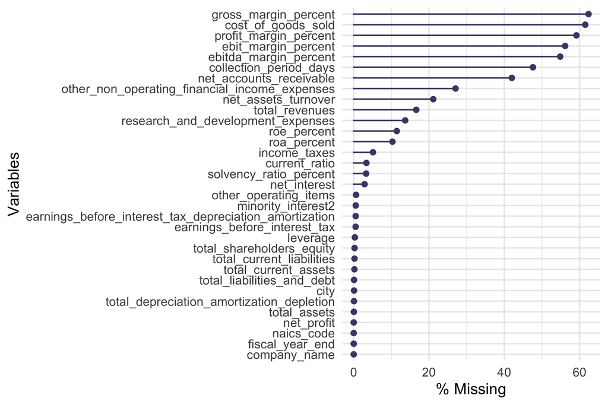

Figure 1: Initial NA

```r
gg_miss_var(au_industry_ts,
            show_pct = TRUE) +
  theme(plot.title = element_text(size = 10))
```

4. In this case, particular emphasis was placed on `profit_margin_percent`. Although the initial missingness examination showed nearly **60%** missingness in this variable, it could be recalculated using other available variables such as `net_profit` and `total_revenues`. Through this approach, the missingness of `profit_margin_percent` was reduced to around **15%**, comparable to the missingness level of total revenue. Further imputation was not possible due to the absence of additional information on revenue or supporting elements.

Total revenues serve as the denominator for key performance ratios. Observations without reported revenues cannot yield interpretable profitability or turnover metrics. After attempts to impute through interpolation failed (due to lack of bounding years), these observations were removed to maintain analytical consistency and ratio integrity.

```r
au_bad_rows <- au_industry_ts %>%
  filter(!is.na(net_profit),
         !is.na(total_revenues),
         net_profit > total_revenues)

au_industry_ts <- au_industry_ts %>%
  filter(!( !is.na(net_profit) &
            !is.na(total_revenues) &
            net_profit > total_revenues ))
au_industry_ts <- au_industry_ts %>%
  filter(is.na(total_revenues) | total_revenues > 0)
```

```r
#australia

vars_to_interp <- c(
  "total_revenues","net_profit","total_assets","total_liabilities_and_debt",
  "earnings_before_interest_tax",
  "earnings_before_interest_tax_depreciation_amortization",
  "total_current_assets","total_current_liabilities",
  "total_shareholders_equity","net_accounts_receivable",
  "research_and_development_expenses","other_operating_items",
  "total_depreciation_amortization_depletion","net_interest",
  "other_non_operating_financial_income_expenses","income_taxes",
  "minority_interest2"
)

au_industry_ts_filled <- au_industry_ts %>%
  arrange(company_name, fiscal_year_end) %>%
  group_by(company_name) %>%
  mutate(across(
    all_of(vars_to_interp),
    ~ na.approx(.x, x = fiscal_year_end, na.rm = FALSE)
  )) %>%
  ungroup()

# Derive metrics ONLY when bases exist
au_industry_ts_filled <- au_industry_ts_filled %>%
  mutate(
    # COGS only if every input exists; otherwise leave NA
    cost_of_goods_sold = if_else(
      is.na(cost_of_goods_sold) &
      !is.na(total_revenues) &
      !is.na(research_and_development_expenses) &
      !is.na(other_operating_items) &
      !is.na(total_depreciation_amortization_depletion) &
      !is.na(net_interest) &
      !is.na(other_non_operating_financial_income_expenses) &
      !is.na(income_taxes) &
      !is.na(minority_interest2) &
      !is.na(net_profit),
      total_revenues
        - research_and_development_expenses
        + other_operating_items
        + total_depreciation_amortization_depletion
        - net_interest
        + other_non_operating_financial_income_expenses
        + income_taxes
        - minority_interest2
        - net_profit,
      cost_of_goods_sold
    ),

    profit_margin_percent = if_else(
      !is.na(net_profit) & !is.na(total_revenues) & total_revenues > 0,
      100 * net_profit / total_revenues, NA_real_
    ),
    leverage = if_else(
      !is.na(total_liabilities_and_debt) & !is.na(total_assets) & total_assets > 0,
      total_liabilities_and_debt / total_assets, NA_real_
    ),
    net_assets_turnover = if_else(
      !is.na(total_revenues) & !is.na(total_assets) & total_assets > 0,
      total_revenues / total_assets, NA_real_
    ),
    gross_margin_percent = if_else(
      !is.na(total_revenues) & total_revenues > 0 & !is.na(cost_of_goods_sold),
      100 * (total_revenues - cost_of_goods_sold) / total_revenues, NA_real_
    ),
    ebit_margin_percent = if_else(
      !is.na(earnings_before_interest_tax) & !is.na(total_revenues) & total_revenues > 0,
      100 * earnings_before_interest_tax / total_revenues, NA_real_
    ),
    ebitda_margin_percent = if_else(
      !is.na(earnings_before_interest_tax_depreciation_amortization) &
      !is.na(total_revenues) & total_revenues > 0,
      100 * earnings_before_interest_tax_depreciation_amortization / total_revenues, NA_real_
    ),
    collection_period_days = if_else(
      !is.na(net_accounts_receivable) & !is.na(total_revenues) & total_revenues > 0,
      365 * net_accounts_receivable / total_revenues, NA_real_
    ),
    roe_percent = if_else(
      !is.na(net_profit) & !is.na(total_shareholders_equity) & total_shareholders_equity > 0,
      100 * net_profit / total_shareholders_equity, NA_real_
    ),
    solvency_ratio_percent = if_else(
      !is.na(total_shareholders_equity) & !is.na(total_assets) & total_assets > 0,
      100 * total_shareholders_equity / total_assets, NA_real_
    ),
    roa_percent = if_else(
      !is.na(net_profit) & !is.na(total_assets) & total_assets > 0,
      100 * net_profit / total_assets, NA_real_
    ),
    current_ratio = if_else(
      !is.na(total_current_assets) & !is.na(total_current_liabilities) & total_current_liabilities > 0,
      total_current_assets / total_current_liabilities, NA_real_
    )
  )
```

```r
# australia
# city not yet defined

au_city_loc <- australia_all_new %>%
  select(post_code_postcode, city, province_provcode) %>%
  distinct()
```

```r
#Australia

au_naics_code <- read_csv("naics_code.csv") %>%
  mutate(
    industry = str_remove(industry, "\\s*T\\s*$"),
    naics_code = as.character(naics_code)
  )

au_industry_ts_filled <- au_industry_ts_filled %>%
  left_join(naics_code, by = "naics_code") %>%
  mutate(industry = if_else(is.na(industry), "Unknown", industry))
```

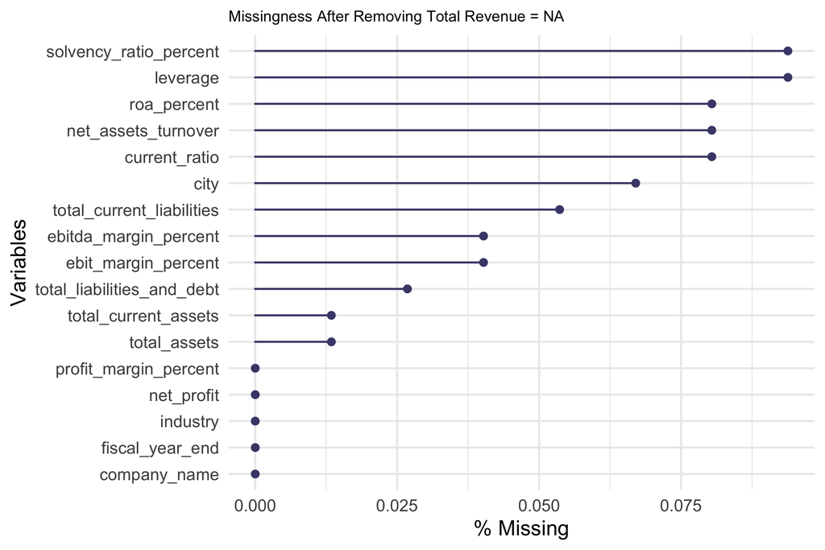

```r
au_industry_ts_clean <- au_industry_ts_filled %>%
  filter(!is.na(total_revenues)) %>%
  select(
        company_name,
        industry,
        fiscal_year_end,
        solvency_ratio_percent,
         leverage,
         roa_percent,
         net_assets_turnover,
         current_ratio,
         city,
         total_current_liabilities,
         ebitda_margin_percent,
         ebit_margin_percent,
         total_liabilities_and_debt,
         total_current_assets,
         total_assets,
         profit_margin_percent,
        net_profit,
         )

gg_miss_var(as_tibble(au_industry_ts_clean),
            show_pct = TRUE) +
  labs(title = "Missingness After Removing Total Revenue = NA") +
  theme(plot.title = element_text(size = 8))
```

6. Another difference is in the geographical identifier. While the Malaysian dataset used standardised city names, the Australian dataset relies on the `post_code` variable, which can be linked to state and coordinate information using the `strayr` package.
7. Finally, the cleaned and processed Australian dataset was combined with the Malaysian dataset by the common variables to form an integrated dataset for further exploration and cross-country comparison, the overall missingness for combined dataset less then 0.5%.

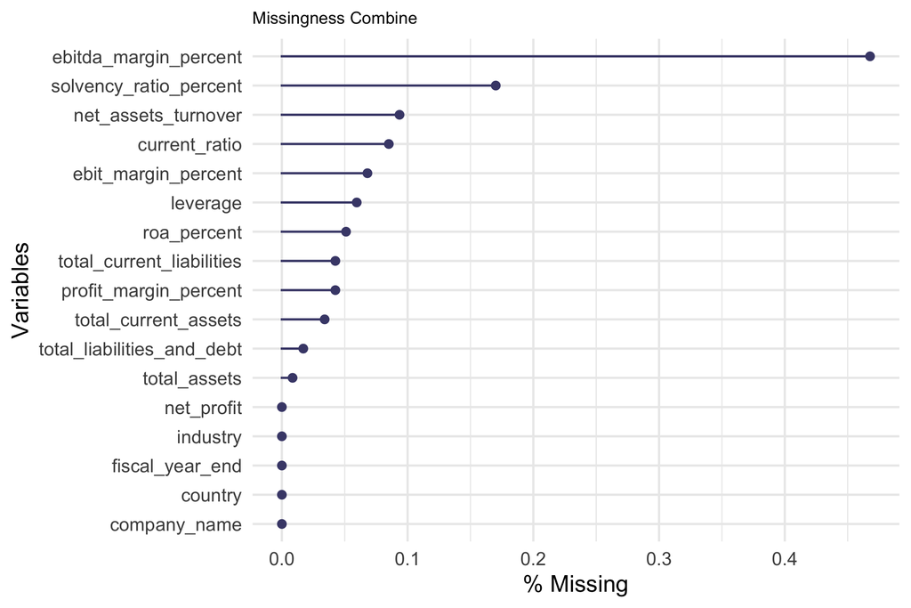

```r
vars <- c("company_name", "industry","fiscal_year_end","solvency_ratio_percent","leverage","roa_percent","net_assets_turnover","current_ratio", "total_current_liabilities","ebitda_margin_percent","ebit_margin_percent","total_liabilities_and_debt","total_current_assets","total_assets","profit_margin_percent", "net_profit")

# Select the columns and tag country
au_sel <- au_industry_ts_clean %>%
  mutate(country = "Australia") %>%
select(country, any_of(vars))

my_sel <- industry_ts_filled %>%
  mutate(country = "Malaysia") %>%
select(country, any_of(vars))

# Bind together
combined_industry_aumy <- bind_rows(au_sel, my_sel)

gg_miss_var(as_tibble(combined_industry_aumy),
            show_pct = TRUE) +
  labs(title = "Missingness Combine ") +
  theme(plot.title = element_text(size = 8))
```

## 3.2 Post-Cleaning Data Inspection

Having completed the data cleaning, interpolation, and structuring, our dataset `combined_industry_aumy` is now ready for inspection. Before exploring trends or relationships between variables, a crucial step in Initial Data Analysis (IDA) is to understand the fundamental characteristics of our key analytical variables: the financial ratios accross both **Malaysia** and **Australia**. This aligns with the core EDA principle of first examining individual variables to understand their features, such as asymmetry, outliers, and central tendency.

We anticipate, based on Project Part 1 and general financial data knowledge, that many ratios will be skewed. By using faceted histograms (**Reference: Week 7**), we can efficiently visualize and compare the distributions. As before, we focus on the central 98% of the data for readability, managing extreme outliers (**Reference: Week 5**). This comparative visual inspection allows us to confirm similarities or differences in data characteristics (like skewness or spread) between the two countries, which is essential context for the EDA section.

```r
combined_industry_aumy_tibble <- as.tibble(combined_industry_aumy)

ratio_metrics1 <- c(
  "profit_margin_percent", "roa_percent", "ebitda_margin_percent", "ebit_margin_percent")

ratio_metrics2 <- c(
  "current_ratio", "net_assets_turnover", "leverage", "solvency_ratio_percent")

plot_data1 <- combined_industry_aumy_tibble %>%
  select(country, all_of(ratio_metrics1)) |>
  pivot_longer(cols = -country, names_to = "variable", values_to = "value") |>
  group_by(country, variable) |>
  filter(
    !is.na(value),
    value > quantile(value, 0.01, na.rm = TRUE) &
    value < quantile(value, 0.99, na.rm = TRUE)
  ) |>
  ungroup()

plot_distribution1 <- plot_data1 |>
  ggplot(aes(x = value, fill = country)) +
  geom_histogram(bins = 40, alpha = 0.8) +
  facet_grid(country ~ variable, scales = "free") +
  scale_fill_manual(values = c("Malaysia" = "#D55E00", "Australia" = "#0072B2" )) +
  labs(
    title = "Distribution of Financial Ratios part A",
    subtitle = "Each variable is plotted on its own x-axis scale"
  ) +
  theme(axis.text.x = element_text(angle = 45, hjust = 1),
        plot.title = element_text(size = 20),
        plot.subtitle = element_text(size = 12),
        strip.text = element_text(size = 7),
        legend.position = "none"
        )

plot_data2 <- combined_industry_aumy_tibble %>%
  select(country, all_of(ratio_metrics2)) |>
  pivot_longer(cols = -country, names_to = "variable", values_to = "value") |>
  group_by(country, variable) |>
  filter(
    !is.na(value),
    value > quantile(value, 0.01, na.rm = TRUE) &
    value < quantile(value, 0.99, na.rm = TRUE)
  ) |>
  ungroup()

plot_distribution2 <- plot_data2 |>
  ggplot(aes(x = value, fill = country)) +
  geom_histogram(bins = 40, alpha = 0.8) +
  facet_grid(country ~ variable, scales = "free") +
  scale_fill_manual(values = c("Malaysia" = "#D55E00", "Australia" = "#0072B2")) +
  labs(
    title = "Distribution of Financial Ratios part B",
    subtitle = "Each variable is plotted on its own x-axis scale"
  ) +
  theme(axis.text.x = element_text(angle = 45, hjust = 1),
        plot.title = element_text(size = 20),
        plot.subtitle = element_text(size = 12),
        strip.text = element_text(size = 7),
        legend.position = "none"
        )

ggplotly(plot_distribution1)
```

[interactive chart not shown]

Figure 2: Histograms for all key numerical variables, each with its own scale.

```r
ggplotly(plot_distribution2)
```

[interactive chart not shown]

Figure 3: Histograms for all key numerical variables, each with its own scale.

**Interpretation of the plots:**

1. Profitability Ratios (Profit Margin Percentage, EBIT, EBITDA Margins):

Both countries also have a lot of left-skewness (long negative tails), which means that big profits are rare but big losses are common in business.

2. Return on Assets (ROA)

This ratio is also close to 0 in both countries and looks more balanced than the profitability margins. The main difference is in the spread. The Australian distribution for roa_percent looks a little wider, which means there is more variance. The Malaysian distribution, on the other hand, is more tightly peaked around the centre.

3. Efficiency & Liquidity (Current Ratio and Nett Assets Turnover)

This pattern is very similar in both countries. The `current_ratio` and `nett_assets_turnover` both have a lot of right-skew (positive skew). This is a common trait of ratios that have a natural floor at 0.

Most of the companies in Malaysia and Australia are at the low end (for example, current_ratio between 0 and 2 and net_assets_turnover between 0 and 1). There are also a lot of companies with much higher values.

4. Leverage & Solvency

The `leverage` and `solvency_ratio_percent` distributions are the same in both countries, which visually confirms the relationship between leverage and solvency.

The distributions are also very similar: both are skewed, with most companies showing leverage that peaked between 0.0 and 0.5 and solvency_ratio_percent that peaked between 50 and 100%. This means that most of the companies in both samples are not mostly funded by debt.

# 4. Exploratory Data Analysis (EDA): Discovering Patterns

In this section, we conduct an exploratory data analysis (EDA) to identify major trends and patterns within the Malaysian corporate dataset.

Using descriptive summaries and visual exploration, we examine overall trends, compare industry groups, investigate relationships between financial indicators, and explore spatial patterns of corporate performance in Malaysia.

## 4.1 Overall Data & Trends

To begin answering our primary question, how the pandemic affected corporate financials, we first need to establish a high-level, aggregate picture. By examining the year-over-year/time series trends of key financial ratios, we can observe the overall health and performance of the Malaysian corporate sector before, during, and after the initial shock of 2020.

Given the significant skewness identified in our Initial Data Analysis (IDA), we will use robust statistical measures. Instead of the mean, which is sensitive to outliers, our analysis will focus on the median (the 50th percentile) to represent the variables. To understand the variability and resilience of the market, we will also visualize the **Median** $\pm$ Median Absolute Deviation (**Reference: Week 5**) because the IQR for Australia have a massive range of outcomes due to the distribution has a severe tail, the 25th percentile will be very far from the median, resulting in a wide ribbon. **The Median Absolute Deviation (MAD)** is an even more robust measure of spread. It focuses on the median deviation from the median, effectively ignoring the most extreme outliers. It provides a narrower, more stable band around the median. This filters out the “noise” from the most extreme outliers (like those at the 25th percentile) and allows you to more clearly see the central trend of the median itself and the variability of the most typical cluster of companies.

```r
# Compute yearly summaries (Median Absolute Deviation (MAD) and Quantile 25th and Quantile 75th)
summary_stats <- combined_industry_aumy_tibble |>
  group_by(fiscal_year_end, country) |>
  summarise(
    median_profit_margin = median(profit_margin_percent, na.rm = T),
    MAD_profit_margin = mad(profit_margin_percent, na.rm = T),
    q25_profit_margin = quantile(profit_margin_percent, 0.25, na.rm = T),
    q75_profit_margin = quantile(profit_margin_percent, 0.75, na.rm = T),

    median_roa_percent = median(roa_percent, na.rm = T),
    MAD_roa_percent = mad(roa_percent, na.rm = T),
    q25_roa_percent = quantile(roa_percent, 0.25, na.rm = T),
    q75_roa_percent = quantile(roa_percent, 0.75, na.rm = T),

    median_ebitda_margin_percent = median(ebitda_margin_percent, na.rm = T),
    MAD_ebitda_margin_percent = mad(ebitda_margin_percent, na.rm = T),
    q25_ebitda_margin_percent = quantile(ebitda_margin_percent, 0.25, na.rm = T),
    q75_ebitda_margin_percent = quantile(ebitda_margin_percent, 0.75, na.rm = T),

    median_ebit_margin = median(ebit_margin_percent, na.rm = T),
    MAD_ebit_margin = mad(ebit_margin_percent, na.rm = T),
    q25_ebit_margin = quantile(ebit_margin_percent, 0.25, na.rm = T),
    q75_ebit_margin = quantile(ebit_margin_percent, 0.75, na.rm = T),

    median_current_ratio = median(current_ratio, na.rm = T),
    MAD_current_ratio = mad(current_ratio, na.rm = T),
    q25_current_ratio = quantile(current_ratio, 0.25, na.rm = T),
    q75_current_ratio = quantile(current_ratio, 0.75, na.rm = T),

    median_net_assets_turnover = median(net_assets_turnover, na.rm = T),
    MAD_net_assets_turnover = mad(net_assets_turnover, na.rm = T),
    q25_net_assets_turnover = quantile(net_assets_turnover, 0.25, na.rm = T),
    q75_net_assets_turnover = quantile(net_assets_turnover, 0.75, na.rm = T),

    median_leverage = median(leverage, na.rm = T),
    MAD_leverage = mad(leverage, na.rm = T),
    q25_leverage = quantile(leverage, 0.25, na.rm = T),
    q75_leverage = quantile(leverage, 0.75, na.rm = T),

    median_solvency_ratio = median(solvency_ratio_percent, na.rm = T),
    MAD_solvency_ratio = mad(solvency_ratio_percent, na.rm = T),
    q25_solvency_ratio = quantile(solvency_ratio_percent, 0.25, na.rm = T),
    q75_solvency_ratio = quantile(solvency_ratio_percent, 0.75, na.rm = T),

    .groups = "drop"
  )

# Visualise the summary stats
#q25_col, q75_col,
plot_indicator <- function(data, fiscal_year_end_col, median_col, MAD_col,  country_col, title, y_label) {
  p <- ggplot(data, aes(x = .data[[fiscal_year_end_col]],
                        group = .data[[country_col]])) +
    geom_line(aes(y = .data[[median_col]], color = .data[[country_col]]), linewidth = 1.2) +
    geom_ribbon(aes(ymin = .data[[median_col]] - .data[[MAD_col]],
                    ymax = .data[[median_col]] + .data[[MAD_col]],
                    fill = .data[[country_col]]),
  alpha = 0.2) +
    labs(title = title, x = "Year", y = y_label, color = "Country", fill = "Country") +
    theme_minimal(base_size = 14) +
    theme(plot.title = element_text(size = 10, face = "bold"), legend.position = "bottom") +
    scale_x_continuous(breaks = scales::pretty_breaks(n = length(unique(data[[fiscal_year_end_col]])))) +
    scale_color_manual(values = c("Malaysia" = "#D55E00", "Australia" = "#0072B2")) +
    scale_fill_manual(values = c("Malaysia" = "#D55E00", "Australia" = "#0072B2"))

  return(p)
}

# Generate a plot for each variable
# 1. Profit Margin
p1 <- plot_indicator(summary_stats, "fiscal_year_end", "median_profit_margin", "MAD_profit_margin", "country", "Profit Margin Trend (2017-2021)", "Profit Margin (%)")

# 2. Return on Assets (ROA)
p2 <- plot_indicator(summary_stats, "fiscal_year_end", "median_roa_percent", "MAD_roa_percent", "country", "Return on Assets (ROA) Trend (2017-2021)", "ROA (%)")

# 3. EBITDA Margin
p3 <- plot_indicator(summary_stats, "fiscal_year_end", "median_ebitda_margin_percent", "MAD_ebitda_margin_percent", "country", "EBITDA Margin Trend (2017-2021)", "EBITDA Margin (%)")

# 4. EBIT Margin
p4 <- plot_indicator(summary_stats, "fiscal_year_end", "median_ebit_margin", "MAD_ebit_margin", "country", "EBIT Margin Trend (2017-2021)", "EBIT Margin (%)")

# 5. Current Ratio
p5 <- plot_indicator(summary_stats, "fiscal_year_end", "median_current_ratio", "MAD_current_ratio", "country", "Current Ratio Trend (2017-2021)", "Ratio")

# 6. Net Assets Turnover
p6 <- plot_indicator(summary_stats, "fiscal_year_end", "median_net_assets_turnover", "MAD_net_assets_turnover", "country", "Net Assets Turnover Trend (2017-2021)", "Net Assets Turnover (%)")

# 7. Leverage
p7 <- plot_indicator(summary_stats, "fiscal_year_end", "median_leverage", "MAD_leverage", "country", "Leverage Trend (2017-2021)", "Leverage (%)")

# 8. Solvency Ratio
p8 <- plot_indicator(summary_stats, "fiscal_year_end", "median_solvency_ratio", "MAD_solvency_ratio", "country", "Solvency Ratio Trend (2017-2021)", "Solvency Ratio (%)")

#the plot
subplot(ggplotly(p1), ggplotly(p2)) |>
  plotly::layout(
    title = paste(
      "Profit Margin and Return on Assets Ratio",
      "<br><span style='font-size: 11px; color: grey;'>",
      "<span style='float: left;'>Profit Margin = Net Profit / Total Revenue&nbsp;&nbsp;&nbsp;&nbsp;&nbsp;&nbsp;&nbsp;&nbsp;&nbsp;&nbsp;&nbsp;ROA = Net Income / Total Assets</span>"),
    annotations = list(
      list(
        text = "<i>Lines = Median, Shaded Area = Median +/- Median Absoulte Deviance (MAD)</i>",
        xref = "paper",
        yref = "paper",
        x = 0.5,
        y = -0.15,
        showarrow = FALSE,
        font = list(size = 12, color = "grey"),
        xanchor = 'center',
        yanchor = 'top'
      )
    ),
    margin = list(b = 80)
  )
```

[interactive chart not shown]

```r
subplot(ggplotly(p3), ggplotly(p4)) |>
  plotly::layout(
    title = paste(
      "EBITDA Margin and EBIT Margin",
      "<br><span style='font-size: 11px; color: grey;'>",
      "<span style='float: left;'>EBITDA Margin = EBITDA / Total Revenue&nbsp;&nbsp;&nbsp;&nbsp;&nbsp;&nbsp;&nbsp;&nbsp;&nbsp;&nbsp;&nbsp;EBIT Margin = EBIT / Total Revenue</span>"),
    annotations = list(
      list(
        text = "<i>Lines = Median, Shaded Area = Median +/- Median Absoulte Deviance (MAD)</i>",
        xref = "paper",
        yref = "paper",
        x = 0.5,
        y = -0.15,
        showarrow = FALSE,
        font = list(size = 12, color = "grey"),
        xanchor = 'center',
        yanchor = 'top'
      )
    ),
    margin = list(b = 80)
  )
```

[interactive chart not shown]

Figure 5: EBITDA Margin and EBIT Margin

Above plots Figure 5, indicating:

```r
subplot(ggplotly(p5), ggplotly(p6)) |>
  plotly::layout(
    title = paste(
      "Current Ratio and Net Assets Turnover ",
      "<br><span style='font-size: 11px; color: grey;'>",
      "<span style='float: left;'>Current Ratio = Current Assets / Current Liabilities&nbsp;&nbsp;&nbsp;&nbsp;&nbsp;&nbsp;&nbsp;&nbsp;&nbsp;&nbsp;Net Assets Turnover = Total Revenues / Total Assets</span>"),
    annotations = list(
      list(
        text = "<i>Lines = Median, Shaded Area = Median +/- Median Absoulte Deviance (MAD)</i>",
        xref = "paper",
        yref = "paper",
        x = 0.5,
        y = -0.15,
        showarrow = FALSE,
        font = list(size = 12, color = "grey"),
        xanchor = 'center',
        yanchor = 'top'
      )
    ),
    margin = list(b = 80)
  )
```

[interactive chart not shown]

Figure 6: Current Ratio and Net Assets Turnover

```r
subplot(ggplotly(p7), ggplotly(p8)) |>
  plotly::layout(
    title = paste(
      "Leverage and Solvency Ratio",
      "<br><span style='font-size: 11px; color: grey;'>",
      "<span style='float: left;'>Leverage = Total Debt / Total Assets&nbsp;&nbsp;&nbsp;&nbsp;&nbsp;&nbsp;&nbsp;&nbsp;&nbsp;&nbsp;&nbsp;&nbsp;Solvency Ratio = Total Shareholder Equity / Total Assets</span>"),
    annotations = list(
      list(
        text = "<i>Lines = Median, Shaded Area = Median +/- Median Absoulte Deviance (MAD)</i>",
        xref = "paper",
        yref = "paper",
        x = 0.5,
        y = -0.15,
        showarrow = FALSE,
        font = list(size = 12, color = "grey"),
        xanchor = 'center',
        yanchor = 'top'
      )
    ),
    margin = list(b = 80)
  )
```

[interactive chart not shown]

Figure 7: Leverage and Solvency Ratio

We can see that in Figure 7:

- **Leverage Ratio**: It shows what percentage of a company’s assets are financed by debt. A ratio of 0.4 means 40% of assets are funded by debt. In 2021, there is a very slight dip in Malaysia’s Leverage Ratio (orange), indicating that, on average, companies slightly reduced their reliance on debt. For Australia’s median Leverage Ratio (blue), it is slightly lower but more volatile. It starts near 0.31 (31%), peaks in 2019, and then drops significantly by 2021 to 0.30 (30%). The much wider shaded MAD area suggests Australian firms have a far greater typical deviation in their debt financing strategies.
- **Solvency Ratio**: This ratio tells us how much of the assets are paid for by the owners’ equity. This ratio [for Malaysia] is very stable, staying just above 60% from 2017 to 2020, just like the leverage ratio. There is a small rise in 2021, which shows that, on average, companies improved their ability to pay their debts by increasing their equity base. For Australia’s median solvency (blue), it is consistently higher than Malaysia’s, fluctuating between 65% and 70%. It also experiences a rise in 2021, mirroring its own drop in leverage and showing an improved average ability to meet long-term obligations.

**Overall summaries**

The analysis from 2017 to 2021 reveals two profoundly different story for the Malaysian and Australian corporate sectors.

The Malaysian sector (orange line) demonstrates remarkable stability and resilience. Its core operational cash-generating ability (EBITDA Margin) remained exceptionally stable, showing almost no negative impact from the 2020 pandemic. The dip in net profitability (Profit Margin, ROA, and EBIT Margin) during that year, paired with the stable EBITDA, strongly suggests the shock was driven by non-cash costs (like depreciation, amortisation, or impairments) rather than a failure of the core business or liquidity. This sector maintained a rock-solid capital structure (Leverage, Solvency) and healthy liquidity (Current Ratio). As a result, when these non-cash pressures eased, all profitability metrics showed a strong recovery in 2021. The primary long-term trend appears to be a slow, steady decline in asset efficiency (Net Assets Turnover).

In summary, the 2020 pandemic merely tested the resilient Malaysian sector, which bent from non-cash charges but did not break. For the Australian sector, the analysis reveals a systemic weakness, where the ‘typical’ median firm is fundamentally unprofitable and highly volatile. The 2020 shock simply amplified this existing, core instability.

And also for further observing or examining each year data with the summary of statistical value (quantile 25, quantile 75 and median), below is the table of the summary statistic value Table 1 (**reference: Week 5**). The following interactive table tracks the median performance and market spread for a comprehensive set of profitability, liquidity, leverage, and efficiency ratios from 2017 to 2021.

```r
datatable(summary_stats,
          caption = "Yearly Summary Statistics of Key Financial Ratios",
          rownames = FALSE,
          options = list(
            scrollX = TRUE,
            searching = TRUE,
            pageLength = 10,
            dom = 'Bfrtip'
          ),
          extensions = 'Buttons',
          filter = 'top'
          ) |>
  formatRound(columns = 3:ncol(summary_stats), digits = 2)
```

Table 1

| fiscal_year_end | country | median_profit_margin | MAD_profit_margin | q25_profit_margin | q75_profit_margin | median_roa_percent | MAD_roa_percent | q25_roa_percent | q75_roa_percent | median_ebitda_margin_percent | MAD_ebitda_margin_percent | q25_ebitda_margin_percent | q75_ebitda_margin_percent | median_ebit_margin | MAD_ebit_margin | q25_ebit_margin | q75_ebit_margin | median_current_ratio | MAD_current_ratio | q25_current_ratio | q75_current_ratio | median_net_assets_turnover | MAD_net_assets_turnover | q25_net_assets_turnover | q75_net_assets_turnover | median_leverage | MAD_leverage | q25_leverage | q75_leverage | … |
| --- | --- | --- | --- | --- | --- | --- | --- | --- | --- | --- | --- | --- | --- | --- | --- | --- | --- | --- | --- | --- | --- | --- | --- | --- | --- | --- | --- | --- | --- | --- |
| 2017 | Australia | -27.77632740340804 | 80.12707951547245 | -612.5422297297298 | 5.450203899839822 | -6.658999691686216 | 20.87202625220968 | -41.97656886824407 | 4.20292749061439 | -23.17127564674398 | 98.65567074744523 | -565.4202596887699 | 14.06643495301408 | -32.73219446171855 | 103.5389163477876 | -629.0463731504872 | 9.428011832008515 | 2.185688810762874 | 1.988612715004593 | 1.124529320115173 | 4.953327729055324 | 0.3305229185693481 | 0.4722282104563527 | 0.04087370908715567 | 0.8714796200876613 | 0.3172664239686561 | 0.3013022878177683 | 0.1191657803660802 | 0.5381824819479657 | … |
| 2017 | Malaysia | 5.416062755034628 | 9.36767369472188 | 0.5940581572119931 | 12.8821001581961 | 3.485860803234333 | 5.307705676512354 | 0.2353630745181001 | 7.525173215545906 | 12.42592661627472 | 12.09216062608567 | 5.251227459520129 | 21.92272062353767 | 8.692996318937793 | 11.12598692941775 | 1.461020616948069 | 16.73131399575538 | 1.956220986905248 | 1.210539432245675 | 1.289981448930145 | 3.341074911891394 | 0.6275080638617458 | 0.5210416841210185 | 0.2958765670520854 | 1.003662015160281 | 0.3744714148511182 | 0.2273419588265783 | 0.2201337941622718 | 0.5261919921300744 | … |
| 2018 | Australia | -46.4373120760786 | 104.4345405299715 | -668.5344827586207 | 4.658677006227236 | -8.099164354318068 | 22.80938006959441 | -42.96147178424648 | 3.785036263799944 | -45.59639389736477 | 125.9313338876764 | -663.960396039604 | 11.66419814771855 | -57.87570621468927 | 134.3397969007827 | -734.5410628019324 | 7.566658388458673 | 2.12512983733407 | 2.009522470325746 | 1.123459715639811 | 5.226874725777837 | 0.3034063193217874 | 0.4374154580092884 | 0.03320828770080193 | 0.8567643538199814 | 0.3111236032057169 | 0.3011102684960678 | 0.1175027245511483 | 0.5363077771514486 | … |
| 2018 | Malaysia | 4.23709886964269 | 10.6744850350394 | -2.707865168539326 | 11.49920508744038 | 2.401058344975952 | 5.653033957799754 | -1.243141009512798 | 6.275052701499765 | 10.44095471262595 | 12.0958962980479 | 3.737643476632454 | 20.87033919127536 | 7.009308404235457 | 11.98002147479911 | -0.9574027750283441 | 15.08972218731863 | 2.051514908595931 | 1.32180842572387 | 1.301756413014264 | 3.476995571594571 | 0.6178342350032008 | 0.5134351109064278 | 0.2848612700228833 | 0.9775374939228151 | 0.3702540407332593 | 0.2231867454617022 | 0.2076042381002121 | 0.5159157688540646 | … |
| 2019 | Australia | -57.09982914327557 | 114.1684840820711 | -630.7851239669421 | 3.318522150852009 | -10.5458087611256 | 24.71577964981747 | -47.28316631753214 | 2.520661971173975 | -45.85052288208769 | 120.5877765980267 | -556.3447725458899 | 11.00478468899522 | -60.54760423148724 | 128.0388975563795 | -602.6239067055394 | 6.080896582018497 | 1.835191674216312 | 1.725416574706604 | 0.9993670249786292 | 4.26633453598062 | 0.3215519384331509 | 0.4626284642266172 | 0.03518917942741875 | 0.8662055189211667 | 0.3486376251905818 | 0.3361205388452119 | 0.1250844603636667 | 0.5804064278668011 | … |
| 2019 | Malaysia | 3.914352626296421 | 10.0995133447277 | -3.354646210486798 | 10.54612062407097 | 1.953490088051552 | 5.344337958183553 | -1.316808675445391 | 5.800450011754038 | 11.00325792380855 | 12.44107986435894 | 3.52840540880727 | 20.14352317248073 | 6.361955628594905 | 12.62621476041209 | -1.66617165647816 | 15.02812050398919 | 2.037010332569696 | 1.337553596632536 | 1.252506500975129 | 3.498521030058809 | 0.5833797752808989 | 0.4647146118724196 | 0.2708562283498456 | 0.9019890486233384 | 0.370643792217108 | 0.2266827922506043 | 0.2184951027830655 | 0.5253128555176336 | … |
| 2020 | Australia | -65.36452586539559 | 124.0096876886382 | -1140.371715865287 | 0.5902436804061555 | -10.09383102791084 | 20.82332309585769 | -38.03457965521829 | 0.3237411386507161 | -51.7719530545026 | 134.4222252249134 | -874.5357142857142 | 11.19083782264634 | -69.20323207759412 | 143.8195431993479 | -957.880320388761 | 3.818968526698536 | 1.988596166990094 | 1.931033227706369 | 1.017271725447826 | 4.869071426820858 | 0.2338342708022585 | 0.3425699926666476 | 0.01562283048671279 | 0.7233344252952171 | 0.3448806672092743 | 0.3660913146228907 | 0.1075329588384911 | 0.609695338727556 | … |
| 2020 | Malaysia | 2.883420952408071 | 11.60084131429661 | -7.634272449087264 | 9.296200073715154 | 1.454920769183864 | 5.748626547236039 | -2.750013912086245 | 4.944272835729206 | 10.98725432824743 | 12.86644869081579 | 3.305515827792823 | 20.92047243024958 | 5.694437025371514 | 12.52963634426163 | -3.181727508477957 | 13.53419926042014 | 2.060614630008138 | 1.437086580635257 | 1.261274648905501 | 3.517235008375557 | 0.531683688171051 | 0.416373089766906 | 0.2549131618347015 | 0.8180574046440164 | 0.3706672163263174 | 0.2216101561437233 | 0.2199668651680229 | 0.5179789347924005 | … |
| 2021 | Australia | -42.15749342855777 | 99.42692928493288 | -808.5928591134817 | 4.061462823094441 | -6.842114241024529 | 18.23106346946166 | -28.5664185988145 | 2.658398582350517 | -34.41361284160251 | 117.1574615313953 | -735.8791208791208 | 14.47003921058905 | -52.78037735264459 | 126.2532912493267 | -773.1555944055945 | 6.999640248170546 | 2.416231804449327 | 2.256236544388893 | 1.171069272243742 | 6.074678981752647 | 0.246942896003549 | 0.3604335599957839 | 0.01504657886895085 | 0.6877576685572213 | 0.3024603241246117 | 0.3135322290763321 | 0.1081414134156153 | 0.5526942930564362 | … |
| 2021 | Malaysia | 4.976299878379045 | 10.87458613151272 | -3.272035441352759 | 11.81661867700857 | 2.480461860259449 | 5.776695199679335 | -1.141432002322451 | 6.458556559008112 | 12.26826743166406 | 12.82861445839628 | 4.852246639839304 | 22.09832553583767 | 7.867930986275351 | 12.36752092620718 | -0.225728952391154 | 16.21558739590195 | 2.155819693426864 | 1.509546862292726 | 1.298642533936652 | 3.817585603829161 | 0.5168246053234965 | 0.4346077006467509 | 0.2423318043767813 | 0.8310676016240397 | 0.3486268726151531 | 0.2195323790485891 | 0.2130097002150727 | 0.5056108794423352 | … |

Interactive data table of summarystatistic

While this overall trend shows that things are generally stable, one of the main ideas behind data exploration is to question these kinds of summaries, since they can often hide important differences .

The overall trend only shows one aspect of performance (like average profit). But a company’s financial health is a complex, high-dimensional story told by the interplay of all its financial ratios. To find these more detailed stories, we need to move from a single time-series view to a scatterplot matrix to explore these high-dimensional relationships and compare them across both countrie

### 4.1.1 High Dimensional View

We will use high-dimensional view approach to see the complex relationship between many variables at once (**Reference: Week 8**). We use the scatterplot matrix to show all pairwise relationship and to spot which correlation are strongest and spot patterns or clusters.

We also use `asinh()` function which is inverse hyperbolic sine to act just like a log-transform (pulling in extreme positive and negative tails to reduce skewness) but is also perfectly stable and defined for zero and negative numbers. This is to meant to practise using “shape changing, transformations” to make the data more symmetrical and the relationships easier to see (**Reference: Week 5**).

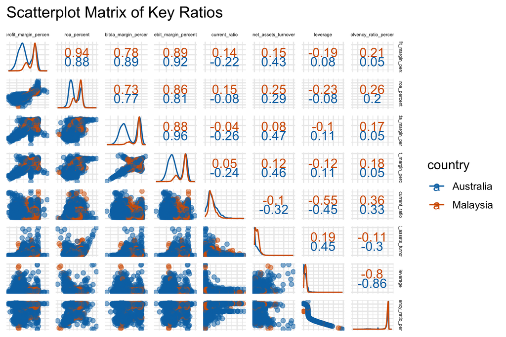

Figure 8: Scatterplot Matrix (Reference Week 8)

```r
splom_data <- combined_industry_aumy_tibble %>%
  select( country, profit_margin_percent, roa_percent, ebitda_margin_percent, ebit_margin_percent, current_ratio, net_assets_turnover, leverage, solvency_ratio_percent ) |>
  mutate(across(where(is.numeric), asinh))

ggscatmat(
  splom_data,
  columns = 2:9,
  color = "country",
  alpha = 0.5
) +
  theme_minimal() +
  labs(x = NULL, y = NULL) +
  theme(
    axis.text.x = element_text(size = 4),
    axis.text.y = element_text(size = 4),
    strip.text  = element_text(size = 4),
    axis.text.x.bottom = element_blank(),
    axis.ticks.x.bottom = element_blank(),
    axis.text.y.left = element_blank(),
    axis.ticks.y.left = element_blank()
  ) +
  ggtitle("Scatterplot Matrix of Key Ratios") +
  scale_color_manual(values = c("Australia" = "#0072B2", "Malaysia" = "#D55E00"))
```

(*Reference: Week 8*)

However, to answer questions such as, ‘Did every industry have the same recovery pattern, or did the pandemic make some industries better off than others?’ So to find these more detailed stories, we need to look at how a specific industry is doing instead of just the overall trend.

## 4.2 Industry Group Trends

The Figure 9 shows the overall shape of profits. Both countries have a good profit cluster on the right, but **Australia has a noticable group of firms on the loss side** and, on top of that, **a group sitting close to break-even (around 0)**. Malaysia’s distribution is tighter on the profit side and has fewer firms running negatives, so the Malaysian sample looks healthier overall.

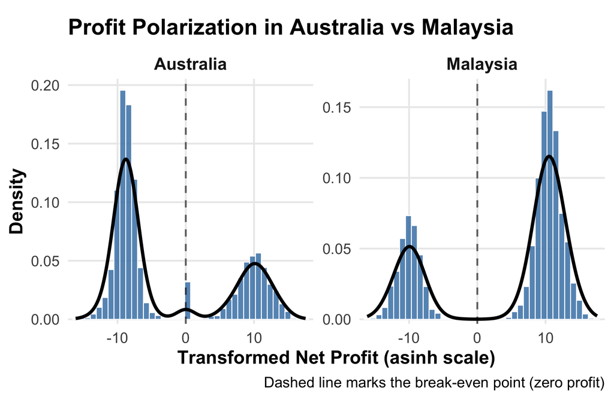

Figure 9: Distribution of net profit in Australia vs Malaysia (asinh-transformed), Improvised from Log Transform in Week 4,5 & 6

```r
# Subset and transform for both countries
industry_profit_au_my <- combined_industry_aumy %>%
  filter(!is.na(net_profit), country %in% c("Australia", "Malaysia")) %>%
  mutate(
    np_asinh = asinh(as.numeric(net_profit))
  )

# Plot side by side using facets
p_compare <- ggplot(industry_profit_au_my, aes(x = np_asinh)) +
  geom_histogram(aes(y = after_stat(density)),
                 bins = 40, fill = "steelblue", color = "white",
                 alpha = 0.85, linewidth = 0.3) +
  geom_density(linewidth = 1.1, color = "black") +
  geom_vline(xintercept = 0, linetype = "dashed", linewidth = 0.6, alpha = 0.6) +
  facet_wrap(~ country, ncol = 2, scales = "free_y") +
  labs(
    title = "Profit Polarization in Australia vs Malaysia",
    x = "Transformed Net Profit (asinh scale)",
    y = "Density",
    caption = "Dashed line marks the break-even point (zero profit)"
  ) +
  scale_x_continuous(expand = expansion(mult = c(0.02, 0.02))) +
  scale_y_continuous(expand = expansion(mult = c(0.02, 0.05))) +
  theme_minimal(base_size = 13) +
  theme( aspect.ratio = 1,
    panel.grid.minor = element_blank(),
    plot.title = element_text(face = "bold"),
    axis.title = element_text(face = "bold"),
    axis.ticks = element_blank(),
    strip.text = element_text(face = "bold", size = 12)
  )

print(p_compare)
```

```r
breakeven_au <- combined_industry_aumy %>%
  filter(country == "Australia", !is.na(net_profit)) %>%
  mutate(np_asinh = asinh(as.numeric(net_profit))) %>%
  filter(np_asinh >= -1 & np_asinh <= 1)
```

```r
breakeven_industries <- breakeven_au %>%
  count(industry, sort = TRUE, name = "n_companies") %>%
  mutate(share = 100 * n_companies / sum(n_companies)) %>%
  slice_head(n = 10)

breakeven_industries %>%
  slice_head(n = 3) %>%
  mutate(share = sprintf("%.2f%%", share)) %>%
  kable(
    col.names = c("Industry", "No. of Companies", "Share of Breakeven Firms"),
    align = c("l", "c", "c")
  )
```

Table 2: Top 3 Small Profit Margin Industry in AU

| Industry | No. of Companies | Share of Breakeven Firms |
| --- | --- | --- |
| Other Financial Investment Activities | 140 | 66.99% |
| Activities Related to Credit Intermediation | 36 | 17.22% |
| Other Investment Pools and Funds | 19 | 9.09% |

The Table 2 then breakdown who is sitting near break-even in Australia. It’s mostly “Other Financial Investment Activities”, “Activities Related to Credit Intermediation”, and “Other Investment Pools and Funds.” These are finance type businesses that can operate with thin margins and, so it makes sense they settle up around zero.

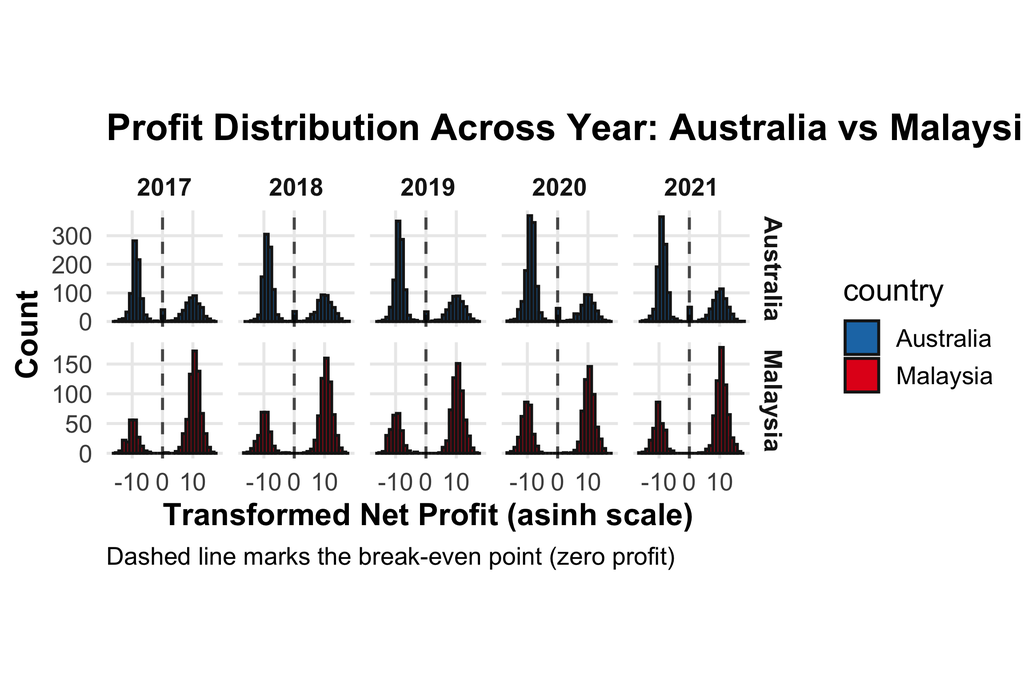

Figure 10: Distribution of net profit across year for Australia vs Malaysia, Improvised from Log Transform in Week 4,5 & 6

```r
p_by_year_aumy <- industry_profit_au_my %>%
  ggplot(aes(x = np_asinh, fill = country)) +
  geom_histogram(bins = 30, color = "grey10", alpha = 1) +
  facet_grid(country ~ fiscal_year_end, scales = "free_y") +
  geom_vline(xintercept = 0, linetype = "dashed", linewidth = 0.6, alpha = 0.7) +
  scale_fill_manual(
    values = c(
      "Australia" = "#1f78b4",
      "Malaysia"  = "#e31a1c"
    )
  ) +
  labs(
    title = "Profit Distribution Across Year: Australia vs Malaysia",
    x = "Transformed Net Profit (asinh scale)",
    y = "Count",
    caption = "Dashed line marks the break-even point (zero profit)"
  ) +
  theme_minimal(base_size = 13) +
  theme(
    aspect.ratio = 1,
    strip.text = element_text(face = "bold"),
    panel.grid.minor = element_blank(),
    plot.title = element_text(face = "bold"),
    axis.title = element_text(face = "bold"),
    axis.ticks = element_blank(),
    plot.caption = element_text(hjust = 0)
  )

p_by_year_aumy
```

```r
ind_year <- combined_industry_aumy %>%
  as_tibble() %>%
  filter(country %in% c("Australia", "Malaysia"),
         fiscal_year_end >= 2017, fiscal_year_end <= 2021) %>%
  group_by(country, industry, fiscal_year_end) %>%
  summarise(
    mean_pm   = mean(profit_margin_percent, na.rm = TRUE),
    n_company = sum(!is.na(profit_margin_percent)),
    .groups = "drop"
  )

# setting eligibility. need at least 2 companies to represent industries and must have complete report of profit margin across five years
eligible <- ind_year %>%
  group_by(country, industry) %>%
  summarise(
    years_ok = n_distinct(fiscal_year_end[n_company >= 2 & !is.na(mean_pm)]) == 5,  # 2017–2021
    min_n    = min(n_company, na.rm = TRUE),
    .groups = "drop"
  ) %>%
  filter(years_ok, is.finite(min_n), min_n >= 2) %>%
  select(country, industry)

top5_profit_margin <- ind_year %>%
  inner_join(eligible, by = c("country","industry")) %>%
  group_by(country, industry) %>%
  summarise(avg5 = mean(mean_pm, na.rm = TRUE), .groups = "drop") %>%
  group_by(country) %>%
  slice_max(avg5, n = 5) %>%
  arrange(country, desc(avg5))
```

```r
# Data for plotting
plot_dat <- ind_year %>%
  inner_join(top5_profit_margin %>% select(country, industry),
             by = c("country","industry")) %>%
  mutate(industry_short = str_trunc(industry, 28))

# Shared axis/legend settings
xaxis_cat <- list(title = "Year", type = "category",
                  categoryorder = "array",
                  categoryarray = c("2017","2018","2019","2020","2021"))
legend_bottom <- list(orientation = "h", x = 0, y = -0.3)
margins <- list(l = 80, r = 40, t = 40, b = 150)

# oz panel
p_au <- plot_ly(
  data  = plot_dat %>% filter(country == "Australia"),
  x     = ~factor(fiscal_year_end),
  y     = ~mean_pm,
  color = ~industry_short,
  colors = "Dark2",
  text  = ~paste0(
    "Country: ", country,
    "<br>Industry: ", industry,
    "<br>Year: ", fiscal_year_end,
    "<br>Mean Profit Margin: ", round(mean_pm, 2), "% ",
    "<br>N companies: ", n_company
  ),
  hoverinfo = "text",
  type = "scatter", mode = "lines+markers",
  marker = list(size = 6), line = list(width = 2)
) %>%
  plotly::layout(
    title = "Australia",
    xaxis = xaxis_cat,
    yaxis = list(title = "Australia",
                 zeroline = TRUE,
                 zerolinecolor = "rgba(0,0,0,0.25)",
                 zerolinewidth = 1),
    legend = c(legend_bottom, list(title = list(text = "Industry (Australia)"))),
    margin = margins,
    hoverlabel = list(bgcolor = "white")
  )

# Malaysia Panel
p_my <- plot_ly(
  data  = plot_dat %>% filter(country == "Malaysia"),
  x     = ~factor(fiscal_year_end),
  y     = ~mean_pm,
  color = ~industry_short,
  colors = "Set1",
  text  = ~paste0(
    "Country: ", country,
    "<br>Industry: ", industry,
    "<br>Year: ", fiscal_year_end,
    "<br>Mean Profit Margin: ", round(mean_pm, 2), "% ",
    "<br>N companies: ", n_company
  ),
  hoverinfo = "text",
  type = "scatter", mode = "lines+markers",
  marker = list(size = 6), line = list(width = 2)
) %>%
  plotly::layout(
    title = "Malaysia",
    xaxis = xaxis_cat,
    yaxis = list(title = "Malaysia",
                 zeroline = TRUE,
                 zerolinecolor = "rgba(0,0,0,0.25)",
                 zerolinewidth = 1),
    legend = c(legend_bottom, list(title = list(text = "Industry (Malaysia)"))),
    margin = margins,
    hoverlabel = list(bgcolor = "white")
  )

# Combine Vertically
plotly::subplot(p_au, p_my, nrows = 2, shareX = TRUE, shareY = FALSE, titleY = TRUE) %>%
  plotly::layout(
    title = list(text = "Top 5 Industries by Average Profit Margin (2017–2021)", x = 0.5)
  )
```

[interactive chart not shown]

Figure 11: Average Profit Margin Movement, Reference Week 9

We start our analysis by looking at the surface level condition of top companies in each countries. Figure 11 shows average profit margins from 2017 to 2021 for industry with highest profit margin. In Australia, the two manufacturing industries, Clay Product & Refractory and Other Fabricated Metal Product Manufacturing, both dip around 2019–2020 and then pick up again in 2021. That shape looks like COVID effect, operations got hit then activity came back. In Malaysia, the pattern is not the same. Lessors of Real Estate peaks early (2018) and keeps sliding through 2019–2020 instead of bouncing. Electric Power Generation, Transmission and Distribution even improves across the period. So straight from Figure 1 we could say the two countries didn’t experience the pandemic through the same channel. That leads to the hypothesis: for Australia we should check operating performance (EBITDA), for Malaysia we should check balance-sheet pressure (leverage).

```r
au_industries <- c(
  "Clay Product and Refractory Manufacturing",
  "Other Fabricated Metal Product Manufacturing"
)

my_industries <- c(
  "Lessors of Real Estate",
  "Electric Power Generation, Transmission and Distribution"
)

focus_data <- combined_industry_aumy %>%
  filter(
    (country == "Australia" & industry %in% au_industries) |
      (country == "Malaysia" & industry %in% my_industries),
    fiscal_year_end %in% 2017:2021
  )
```

```r
au_plot_raw <- combined_industry_aumy %>%
  filter(
    country == "Australia",
    industry %in% c(
      "Clay Product and Refractory Manufacturing",
      "Other Fabricated Metal Product Manufacturing"
    ),
    fiscal_year_end %in% 2017:2021
  ) %>%
  ggplot(aes(x = ebitda_margin_percent,
             y = profit_margin_percent,
             color = factor(fiscal_year_end))) +
  geom_point(alpha = 0.6) +
  geom_smooth(method = "lm", se = FALSE, color = "black") +
  facet_wrap(
    ~ industry,
    labeller = label_wrap_gen(width = 28)   # Wrap long names
  ) +
  labs(
    title = "Australia: operating margins vs profit",
    x = "EBITDA margin (%)",
    y = "Profit margin (%)",
    color = "Year"
  ) +
  theme_minimal(base_size = 12) +
  theme(
    aspect.ratio = 1,
    plot.title = element_text(hjust = 0.5, face = "bold", size = 12),
    strip.text = element_text(face = "bold", size = 11),
    legend.position = "bottom"
  )

ggplotly(au_plot_raw) %>%
 plotly::layout(
    title = list(
      text = "Australia: operating margins vs profit<br><sup>EBITDA Margin vs Profit Margin, 2017–2021</sup>",
      x = 0.5,
      y = 1.5
    ),
    margin = list(t = 150)
  )
```

[interactive chart not shown]

Figure 12: Profit vs Operating Margin For Clay and Metal, Reference Week 6, 7, & 10

So we test the Australian part first. In Figure 12 we plot profit margin vs EBITDA margin for those two Australian industries. For Clay Product & Refractory the line is steep and clean. When EBITDA is high, profit is high. When EBITDA is low, profit is low. That confirms our guess, the 2020 dip in Figure 11 was mainly an operating related issue. For Other Fabricated Metal Product Manufacturing the line is still upward but not as strong. That tells us EBITDA helps, but it doesn’t fully explain why its profit moved up and down. Because of that weaker slope, we probably this industry are experiencing other problem.

```r
ofmpm_au <- combined_industry_aumy %>%
  filter(
    country == "Australia",
    industry == "Other Fabricated Metal Product Manufacturing",
    fiscal_year_end %in% 2017:2021
  )
```

```r
ofmpm_au_all <- bind_rows(
  as_tibble(ofmpm_au) %>%
    mutate(view = "All obs"),
  as_tibble(ofmpm_au) %>%
    filter(profit_margin_percent > 0) %>%
    mutate(view = "No loss-making obs")
)
```

```r
ofpm_plot <- ggplot(ofmpm_au_all,
       aes(x = leverage, y = profit_margin_percent,
           color = factor(fiscal_year_end))) +
  geom_point(size = 3, alpha = 0.9) +
  geom_smooth(method = "lm", se = FALSE, color = "black") +
  facet_wrap(~ view) +
  labs(
    title = "AU – Other Fabricated Metal Product Mfg.",
    x = "Leverage (debt / assets)",
    y = "Profit margin (%)",
    color = "Year"
  ) +
  theme_minimal(base_size = 12) +
  theme(
    aspect.ratio = 1,
    plot.title = element_text(hjust = 0.5, face = "bold", size = 14),
    strip.text = element_text(face = "bold", size = 12),
    axis.title = element_text(face = "bold"),
    legend.position = "bottom"
  )

ggplotly(ofpm_plot) %>%
 plotly::layout(
    title = list(
      text = "AU – Other Fabricated Metal Product Mfg<br><sup>Leverage (debt/assets) vs profit margin, 2017–2021</sup>",
      x = 0.5,
      y = 1.5
    ),
    margin = list(t = 150)
  )
```

[interactive chart not shown]

Figure 13: Profit vs Leverage for Metal, Reference Week 6, 7, & 10

That’s why we looked at Figure 13, still for Australia, but now profit vs leverage and only for Other Fabricated Metal Product Manufacturing. Here the slope still goes down even after removing the bad point in, so firms with higher debt-to-asset ratios tended to earn lower profit. This means the Australian story is slightly two layered: one industry (clay) is clearly operations-led, the other (metal) is mostly operations-led but debt made the bad years worse.

```r
my_data <- combined_industry_aumy %>%
  filter(
    country == "Malaysia",
    industry %in% c(
      "Lessors of Real Estate",
      "Electric Power Generation, Transmission and Distribution"
    ),
    fiscal_year_end %in% 2017:2021
  )
```

```r
p_my_lev <- my_data %>%
  ggplot(aes(x = leverage,
             y = profit_margin_percent,
             color = factor(fiscal_year_end))) +
  geom_point(size = 3, alpha = 0.9) +
  geom_smooth(method = "lm", se = FALSE, color = "black") +
  facet_wrap(
    ~ industry,
    scales = "free_x",                     # free x only
    labeller = label_wrap_gen(width = 28)
  ) +
  coord_cartesian(ylim = c(-50, 100)) +    # same y for all panels
  labs(
    title = "Malaysia: Profitability vs Leverage",
    subtitle = "Leverage (debt/assets) vs profit margin, 2017–2021",
    x = "Leverage (total liabilities / total assets)",
    y = "Profit margin (%)",
    color = "Year"
  ) +
  theme_minimal(base_size = 12) +
  theme(
    aspect.ratio = 1,
    plot.title = element_text(hjust = 0.5, face = "bold", size = 14),
    strip.text = element_text(face = "bold", size = 11),
    legend.position = "bottom"
  )

ggplotly(p_my_lev) %>%
 plotly::layout(
    title = list(
      text = "Malaysia: Profitability vs Leverage<br><sup>Leverage (debt/assets) vs profit margin, 2017–2021</sup>",
      x = 0.5,
      y = 1.5
    ),
    margin = list(t = 150)
  )
```

[interactive chart not shown]

Figure 14: Profit vs Leverage for Malaysia Companies, Reference Week 6, 7, & 10

Then we move to Malaysia and check if our second part of the hypothesis holds. In Figure 14 we plot profit vs leverage for Lessors of Real Estate and Electric Power. For power the pattern is clear: inside the same industry and over the same years, the firms with more debt report lower profit, even though in Figure 11 the industry average was improving. For real estate the dots are wider but the line is still down, which is exactly what we expected for an asset-heavy sector in COVID.

```r
my <- my_data %>%
  ggplot(aes(x = current_ratio,
             y = profit_margin_percent,
             color = factor(fiscal_year_end))) +
  geom_point(size = 3, alpha = 0.9) +
  geom_smooth(method = "lm", se = FALSE, color = "black") +
  facet_wrap(
    ~ industry,
    scales = "free_x",
    labeller = label_wrap_gen(width = 28)
  ) +
  coord_cartesian(ylim = c(-50, 100)) +
  labs(
    title = "Malaysia: liquidity and profitability",
    subtitle = "Current ratio vs profit margin, 2017–2021",
    x = "Current ratio",
    y = "Profit margin (%)",
    color = "Year"
  ) +
  theme_minimal(base_size = 12) +
  theme(
    aspect.ratio = 1,
    plot.title = element_text(hjust = 0.5, face = "bold", size = 14),
    strip.text = element_text(face = "bold", size = 11),
    legend.position = "bottom"
  )

ggplotly(my) %>%
 plotly::layout(
    title = list(
      text = "Malaysia: liquidity and profitability<br><sup>Current ratio vs profit margin, 2017–2021</sup>",
      x = 0.5,
      y = 1.5
    ),
    margin = list(t = 150)
  )
```

[interactive chart not shown]

Figure 15: Profit vs Current Ratio for Malaysia Companies, Reference Week 6, 7, & 10

To make sure it wasn’t just a short-term cash problem, we checked liquidity in Figure 15 (profit vs current ratio). The lines there are almost flat, so liquidity is not the main story, leverage is.

Overall, Australia’s Clay Product and Refractory Manufacturing and Other Fabricated Metal Product Manufacturing showed an operating style COVID effect. Margins lower when activity and costs were hit, then improved again when EBITDA recovered. In contrast, Malaysia’s Lessors of Real Estate and Electric Power Generation, Transmission and Distribution were different, companies that relied more on debt tended to keep lower profit margins even when the industry looked steady. So for this 2017–2021 trend the story is Australia’s industries were mainly EBITDA driven, while Malaysia’s were affected by the leverage.

## 4.3 Spatial Patterns

This section compares the spatial distribution of company profitability between Malaysia and Australia from 2017 to 2021. A slight difference exists in the mapping approach where Malaysian companies were mapped using standardised city data, while Australian companies were mapped using postcode-level data. The Australian mapping employed the `strayr` package to infer coordinates from postcodes, resulting in a more precise spatial representation, as each point covers a smaller area. However, this improvement in spatial accuracy does not significantly alter the overall interpretive patterns. Both maps in Figure 16 and Figure 17 visualize the head-office locations of profitable (green) and unprofitable (red) companies over time, allowing us to observe spatial concentration and temporal changes before, during, and after the pandemic period.

```r
my_cities_coord <- read_csv("my_cities_coord.csv")

malaysia_city_list_coord <- malaysia_city_list %>%
  left_join(
    my_cities_coord %>% select(std_city, lat, long),
    by = "std_city"
  )

malaysia_city_list <- malaysia_city_list %>%
  distinct(std_city, .keep_all = TRUE)

city_state_check <- industry_ts_filled %>%
  as_tibble() %>%
  filter(!is.na(std_city)) %>%
  select(company_name, industry, fiscal_year_end, net_profit, std_city) %>%
  left_join(
    malaysia_city_list_coord %>% select(std_city, std_state, lat, long),
    by = "std_city"
  ) %>%
  select(company_name, industry, fiscal_year_end, net_profit, std_city, std_state, lat, long)

spatial_plot <- leaflet(city_state_check) %>%
  addProviderTiles("CartoDB.Positron")

years_chr <- sort(unique(city_state_check$fiscal_year_end)) %>% as.character()

for (yr in years_chr){
  company_map <- city_state_check %>% filter(fiscal_year_end == as.integer(yr))

  spatial_plot <- spatial_plot %>%
    addCircleMarkers(
      data = company_map,
      lng = ~long, lat = ~lat,
      radius = 7,
      stroke = TRUE,
      weight = 2,
      color = ~ifelse(net_profit > 0, "#2E8B57", "#FF4500"),
      opacity = 1,
      fill = TRUE,
      fillColor = ~ifelse(net_profit > 0, "#2E8B57", "#FF4500"),
      fillOpacity = 0.9,
      label = ~paste0(std_city, " - ", company_name),
      popup = ~paste0(
        "<b>", company_name, "</b><br/>",
        industry, "<br/>",
        std_city, ", ", std_state, "<br/>",
        "Year: ", fiscal_year_end, "<br/>",
        "Net profit: ", comma(net_profit)
      ),
      group = as.character(yr)
    )
}

spatial_plot <- spatial_plot %>%
  addLayersControl(
    baseGroups = years_chr,
    options = layersControlOptions(collapsed = FALSE)
  ) %>%

  addLegend(
    position = "bottomleft",
    colors = c("#2E8B57", "#FF4500"),
    labels = c("Profitable Company", "Unprofitable Company"),
    title = "Profitability Status"
  )

if (nrow(city_state_check) > 0) {
  spatial_plot <- spatial_plot %>% fitBounds(min(company_map$long), min(company_map$lat), max(company_map$long), max(company_map$lat))
}

spatial_plot
```

[interactive chart not shown]

Figure 16: Spatial Mapping for Malaysian Company Profitability, Reference Assignment 1

In Malaysia, profitable companies were largely concentrated in West Malaysia, particularly around Kuala Lumpur, Selangor, and Johor—while unprofitable firms appeared more scattered, including in East Malaysia. During the pandemic years (2020–2021), there was a visible rise in unprofitable firms, especially in eastern regions, though the overall spatial pattern remained dominated by the central economic corridor around the capital.

```r
au_spatial <- combined_industry_aumy %>%
  distinct(company_name, fiscal_year_end, .keep_all = TRUE) %>%
  filter(country == 'Australia') %>%
  select(company_name, industry, fiscal_year_end, net_profit) %>%
  left_join(
    australia_all_new %>%
      mutate(fiscal_year = year(company_fiscal_year_end_date_closdate)) %>%
      distinct(company_name_name, fiscal_year, .keep_all = TRUE) %>%
      select(company_name_name,
             fiscal_year,
             city,
             postcode = post_code_postcode,
             state = province_provcode),
    by = c("company_name"     = "company_name_name",
           "fiscal_year_end"  = "fiscal_year")
  ) %>%
  select(company_name, industry, fiscal_year_end, net_profit, city, postcode, state)

au_postcode_centroids <- strayr::read_absmap("postcode2021") %>%
  select(postcode_2021, cent_lat, cent_long)

au_city_state_check <- au_spatial %>%
  left_join(au_postcode_centroids, by = c("postcode" = "postcode_2021")) %>%
  filter(!is.na(cent_lat), !is.na(cent_long)) %>%
  mutate(col_hex = if_else(net_profit > 0, "#2E8B57", "#FF4500"))

years_chr <- sort(unique(au_city_state_check$fiscal_year_end)) %>% as.character()

au_spatial_plot <- leaflet(au_city_state_check) %>%
  addProviderTiles("CartoDB.Positron")

for (yr in years_chr) {
  au_company_map <- au_city_state_check %>% filter(fiscal_year_end == as.integer(yr))

  au_spatial_plot <- au_spatial_plot %>%
    addCircleMarkers(
      data = au_company_map,
      lng = ~cent_long, lat = ~cent_lat,
      radius = 7, stroke = TRUE, weight = 2,
      color = ~col_hex, fill = TRUE, fillColor = ~col_hex,
      fillOpacity = 0.9, opacity = 1,
      label = ~paste0(city, " - ", company_name),
      popup = ~paste0(
        "<b>", company_name, "</b><br/>",
        industry, "<br/>",
        city, ", ", postcode, ", ", state, "<br/>",
        "Year: ", fiscal_year_end, "<br/>",
        "Net profit: ", comma(net_profit)
      ),
      group = yr
    )
}

au_spatial_plot <- au_spatial_plot %>%
  addLayersControl(
    baseGroups = years_chr,
    options = layersControlOptions(collapsed = FALSE)
  ) %>%

  addLegend(
    position = "bottomleft",
    colors = c("#2E8B57", "#FF4500"),
    labels = c("Profitable Company", "Unprofitable Company"),
    title = "Profitability Status"
  )

if (nrow(au_city_state_check) > 0) {
  au_spatial_plot <- au_spatial_plot %>%
    fitBounds(
      min(au_city_state_check$cent_long), min(au_city_state_check$cent_lat),
      max(au_city_state_check$cent_long), max(au_city_state_check$cent_lat)
    )
}

au_spatial_plot
```

[interactive chart not shown]

Figure 17: Spatial Mapping for Australian Company Profitability, Reference Assignment 1, Week 10

In contrast, Australian companies displayed a more dispersed yet coastal-oriented distribution. Profitable firms were mainly concentrated along the eastern and southeastern area including Sydney, Melbourne, and Brisbane, with smaller clusters around Perth and Adelaide. The inland regions showed minimal business presence, consistent with Australia’s population and industry concentration near coastal cities. Similar to Malaysia, there was a modest increase in unprofitable firms during 2020–2021, particularly in metropolitan areas most affected by lockdowns.

An interesting observation emerged in the Northern Territory, where only one company, Enova Mining Limited, appeared on the map in 2018 with a negative net profit. Upon tracing the original dataset, only two companies were initially listed in the Northern Territory: `Enova Mining Limited` and `Verdant Minerals Ltd`. The latter was delisted in 2018, while `Enova Mining` had incomplete records for other years (see Table 3). Consequently, only this single company appeared in one year (2018) for that region. The presence of only one listed company over five years indicates an extremely limited corporate presence in the region.

```r
au_north_check <- australia_all_new %>%
  select(
    company_name = company_name_name,
    post_code = post_code_postcode,
    city,
    state = province_provcode,
    status,
    fiscal_year_end = company_fiscal_year_end_date_closdate,
    listed_status = listed_unlisted_delisted_status_listed
  ) %>%
  mutate(fiscal_year = year(fiscal_year_end)) %>%
  distinct(company_name, fiscal_year, .keep_all = TRUE) %>%
  filter(state == "NT", post_code < 1000) %>%
  arrange(company_name, fiscal_year_end) %>%
  select(company_name, city, state, fiscal_year, listed_status) %>%
  kable(
    caption = "Northern Territory companies with postcode < 1000",
    col.names = c(
      "Company", "City", "State", "Fiscal Year", "Listed"
    ),
    align = "llccc"
  )

au_north_check %>%
  kableExtra::kable_styling(
    bootstrap_options = c("striped", "hover", "condensed"),
    full_width = FALSE,
    position = "center"
  )
```

| Company | City | State | Fiscal Year | Listed |
| --- | --- | --- | --- | --- |
| ENOVA MINING LIMITED | DARWIN | NT | 2017 | Listed |
| ENOVA MINING LIMITED | DARWIN | NT | 2018 | Listed |
| ENOVA MINING LIMITED | DARWIN | NT | 2019 | Listed |
| ENOVA MINING LIMITED | DARWIN | NT | 2020 | Listed |
| ENOVA MINING LIMITED | DARWIN | NT | 2021 | Listed |
| VERDANT MINERALS LTD | STUART PARK | NT | 2017 | Delisted |
| VERDANT MINERALS LTD | STUART PARK | NT | 2018 | Delisted |

It is important to note that the spatial mapping reflects company head-office locations rather than their full operational coverage. Many firms operate across multiple regions, so the observed clustering primarily indicates the administrative and financial centres of corporate activity rather than the full spatial extent of their operations.

# 5. Conclusions

This exploratory data analysis set out to compare the financial environments of listed companies in Malaysia and Australia, focusing on the disruptive period of the COVID-19 pandemic (2017-2021). Our analysis of key financial ratios, based on the OSIRIS dataset, reveals a story of shared shocks but distinct national profiles.

Answering the Core Question: The pandemic’s impact was clearly visible in both countries, but its signature was different.

- **The Malaysian Story**: Resilience & Stability. The Malaysian sector demonstrated remarkable stability. Its core operational cash-generating ability (median EBITDA Margin) remained exceptionally stable and positive (around 10-12%). The minor dips seen in EBIT Margin and ROA in 2020 strongly suggest the shock was driven by non-cash costs (like depreciation or impairments) rather than a failure of core operations. This sector maintained a rock-solid capital structure (stable Leverage, high Solvency) and healthy liquidity (Current Ratio ~2.0).
- **The Australian Story**: Volatility & Unprofitability. In stark contrast, the Australian sector is characterized by systemic volatility and deep-seated unprofitability. The Median $\pm$ MAD analysis shows that the “typical” median company is fundamentally unhealthy, with core medians for Profit Margin (down to -75%) and EBITDA Margin (down to -50%) being deeply negative. The wide shaded MAD areas confirm that the “typical” deviation from this already-poor median is also exceptionally large.
- **Financial Discipline & Efficiency**: Both countries showed financial conservatism, with no significant rise in median Leverage. However, Net Assets Turnover (efficiency) revealed a key difference: Malaysian firms were significantly more efficient (median ~0.6) than their Australian counterparts (median ~0.3).

Surprising Findings & Industry Differences: The most interesting findings came from drilling down into the data:

- **The “Rich vs. Poor” Gap**: In Malaysia, the 2020 profitability distribution (Figure 10) revealed a “polarization” effect, where the cluster of unprofitable firms grew larger while the profitable cluster remained stable. This suggests the pandemic widened the gap between struggling and successful firms.
- **Industry Divergence**: The pandemic’s impact was not uniform, and our drill-down revealed a key difference in how top industries were affected. Australia’s top industries (like Clay Product and Other Fabricated Metal) showed an operational-style COVID effect, where profits recovered as EBITDA recovered. In contrast, Malaysia’s top industries (like Lessors of Real Estate and Electric Power) showed a different story, where firms that relied more on leverage tended to have lower profit margins, even if the industry average looked stable.”
- **Spatial Clustering**: Both countries show a heavy concentration of corporate head offices in their primary economic hubs (Kuala Lumpur/Selangor in Malaysia; Sydney/Melbourne in Australia). The spatial maps (Figure 16 and Figure 17) show that both profitable (green) and unprofitable (red) firms coexist within these same hubs, indicating that geography alone is not a simple predictor of success. In contrast, certain regions such as Australia’s Northern Territory exhibit an extremely limited corporate presence, with only one listed company appearing across all observed years, reflecting the highly uneven distribution of corporate activity across the country.

**In conclusion**, while firms in both countries faced the same 2020 downturn, the “average” Malaysian firm entered the pandemic with higher profitability and efficiency and exhibited less volatility than the “average” Australian firm. The most surprising similarity was the shared financial conservatism, with no significant rise in median leverage. This EDA successfully highlights that while the pandemic was a global event, its impact was filtered through distinct national and industrial structures.

## Resources

The materials used for this report are:

Achim Zeileis, Torsten Hothorn (2002). Diagnostic Checking in Regression Relationships. R News 2(3), 7-10. URL https://CRAN.R-project.org/doc/Rnews/

Bureau van Dijk Electronic Publishing. (n.d.). Osiris. Bureau van Dijk Electronic Publishing. https://ezproxy.lib.monash.edu.au/login?url=http://osiris.bvdep.com/ip

C. Sievert. Interactive Web-Based Data Visualization with R, plotly, and shiny. Chapman and Hall/CRC Florida, 2020.

Cambon J, Hernangómez D, Belanger C, Possenriede D (2021). tidygeocoder: An R package for geocoding. Journal of Open Source Software, 6(65), 3544, https://doi.org/10.21105/joss.03544 (R package version 1.0.6)

Cheng J, Schloerke B, Karambelkar B, Xie Y (2024). *leaflet: Create Interactive Web Maps with the JavaScript ‘Leaflet’ Library*. R package version 2.2.2, https://CRAN.R-project.org/package=leaflet.

Firke S (2024). *janitor: Simple Tools for Examining and Cleaning Dirty Data*. R package version 2.2.1, https://CRAN.R-project.org/package=janitor.

Garrett Grolemund, Hadley Wickham (2011). Dates and Times Made Easy with lubridate. Journal of Statistical Software, 40(3), 1-25. URL https://www.jstatsoft.org/v40/i03/.

Hester J, Bryan J (2024). *glue: Interpreted String Literals*. R package version 1.8.0, https://CRAN.R-project.org/package=glue.

O’Hara-Wild M, Hyndman R, Wang E (2025). *feasts: Feature Extraction and Statistics for Time Series*. R package version 0.4.2, https://CRAN.R-project.org/package=feasts.

Ooms J (2025). *writexl: Export Data Frames to Excel ‘xlsx’ Format*. R package version 1.5.4, https://CRAN.R-project.org/package=writexl.

Wang, E, D Cook, and RJ Hyndman (2020). A new tidy data structure to support exploration and modeling of temporal data, Journal of Computational and Graphical Statistics, 29:3, 466-478, doi:10.1080/10618600.2019.1695624.

Waring E, Quinn M, McNamara A, Arino de la Rubia E, Zhu H, Ellis S (2022). *skimr: Compact and Flexible Summaries of Data*. R package version 2.1.5, https://CRAN.R-project.org/package=skimr.

Wickham H, Averick M, Bryan J, Chang W, McGowan LD, François R, Grolemund G, Hayes A, Henry L, Hester J, Kuhn M, Pedersen TL, Miller E, Bache SM, Müller K, Ooms J, Robinson D, Seidel DP, Spinu V, Takahashi K, Vaughan D, Wilke C, Woo K, Yutani H (2019). “Welcome to the tidyverse.” *Journal of Open Source Software*, *4*(43), 1686. doi:10.21105/joss.01686 https://doi.org/10.21105/joss.01686.

Wickham H. ggplot2: Elegant Graphics for Data Analysis. Springer-Verlag New York, 2016.

Wickham H (2023). *conflicted: An Alternative Conflict Resolution Strategy*. doi:10.32614/CRAN.package.conflicted https://doi.org/10.32614/CRAN.package.conflicted, R package version 1.2.0, https://CRAN.R-project.org/package=conflicted.

Wickham H, Henry L (2025). *purrr: Functional Programming Tools*. R package version 1.1.0, https://CRAN.R-project.org/package=purrr.

Wickham H (2023). *stringr: Simple, Consistent Wrappers for Common String Operations*. R package version 1.5.1, https://CRAN.R-project.org/package=stringr.

Wickham H, Hester J, Bryan J (2024). *readr: Read Rectangular Text Data*. R package version 2.1.5, https://CRAN.R-project.org/package=readr.

Wickham H (2023). *stringr: Simple, Consistent Wrappers for Common String Operations*. R package version 1.5.1, https://CRAN.R-project.org/package=stringr.

Wickham H, Pedersen T, Seidel D (2025). *scales: Scale Functions for Visualization*. R package version 1.4.0, https://CRAN.R-project.org/package=scales

Wikipedia contributors. (2025, October 17). List of cities in Malaysia. In Wikipedia. https://en.wikipedia.org/wiki/List_of_cities_in_Malaysia

Pedersen T (2025). *patchwork: The Composer of Plots*. R package version 1.3.2, https://CRAN.R-project.org/package=patchwork.

Robinson D, Hayes A, Couch S (2025). *broom: Convert Statistical Objects into Tidy Tibbles*. R package version 1.0.9, https://CRAN.R-project.org/package=broom.

Tierney N, Cook D (2023). “Expanding Tidy Data Principles to Facilitate Missing Data Exploration, Visualization and Assessment of Imputations.” *Journal of Statistical Software*, *105*(7), 1-31. doi:10.18637/jss.v105.i07 https://doi.org/10.18637/jss.v105.i07.

U.S. Census Bureau. (n.d.). NAICS code identification tools. U.S. Department of Commerce. https://www.census.gov/naics/

Xie Y, Cheng J, Tan X (2024). *DT: A Wrapper of the JavaScript Library ‘DataTables’*. R package version 0.33, https://CRAN.R-project.org/package=DT.

Zeileis A, Grothendieck G (2005). “zoo: S3 Infrastructure for Regular and Irregular Time Series.” *Journal of Statistical Software*, *14*(6), 1-27. doi:10.18637/jss.v014.i06 https://doi.org/10.18637/jss.v014.i06.

Zeileis A, Köll S, Graham N (2020). “Various Versatile Variances: An Object-Oriented Implementation of Clustered Covariances in R.” *Journal of Statistical Software*, *95*(1), 1-36. doi:10.18637/jss.v095.i01 https://doi.org/10.18637/jss.v095.i01.

Zhu H (2024). *kableExtra: Construct Complex Table with ‘kable’ and Pipe Syntax*. R package version 1.4.0, https://CRAN.R-project.org/package=kableExtra.

Wang, E, D Cook, and RJ Hyndman (2020). A new tidy data structure to support exploration and modeling of temporal data, Journal of Computational and Graphical Statistics, 29:3, 466-478, doi:10.1080/10618600.2019.1695624.

Mackey W, Johnson M, Diviny D, Cowgill M, Roney B, Lai W, Wee B (2025). *strayr: Ready-to-use Australian common structures and classifications and tools for working with them*. R package version 0.2.3, commit 38407a77fa66089c9df27b7ddf6eca6a443f935f, https://github.com/runapp-aus/strayr.

Schloerke B, Cook D, Larmarange J, Briatte F, Marbach M, Thoen E, Elberg A, Crowley J (2025). *GGally: Extension to ‘ggplot2’*. doi:10.32614/CRAN.package.GGally https://doi.org/10.32614/CRAN.package.GGally, R package version 2.4.0, https://CRAN.R-project.org/package=GGally.

The links to my use of ChatGPT for help on this assignment are:

- https://chatgpt.com/share/68f604c6-38b0-8003-8711-b83386cd7b8e
- https://chatgpt.com/share/68f6040e-689c-8000-85cc-79f9d3752e60
- https://chatgpt.com/share/68f646f5-5460-8012-bbb5-51e8240372bf